# Discussion section 03

Matthew Garvin

# Part 1: Walkthrough - refer to existing variables in plaintext

Suppose you have done some heavy-lifting calculation and would like to refer to a variable that you have created in a code chunk. Can Rmarkdown handle it?

```r
date_today = Sys.Date()
date_today
```

```
## [1] "2020-09-24"
```

Then, to refer to the text stored in `date_today`, you can typeset the following sentence using such variable: “Today is 2020-09-24”. With the same syntax, you can even display the content of the variable in a standalone code chunk.

This will be useful in writing answers in plain text, if needed. Once you knit the file, notice how the line written below is displayed.

```
Today is 2020-09-24
```

# Part 2: Normal distribution, with mean and standard deviation

In R, we can use function `rnorm` to obtain random samples from a certain Normal distribution. For this part, do not worry about understanding the code. Focus on the concepts first, we will get to the code later in the semester.

## Step 1: simulate a few random variables

```r
library(ggplot2)
set.seed(1)
the_mean <- 0
the_standard_deviation <- 1
sim_count = 1000000 # a million simulations
df <- data.frame(v01 = rnorm(sim_count,
                            mean = the_mean,
                            sd = the_standard_deviation
                 ),
                 v02 = rnorm(sim_count,
                            mean = the_mean,
                            sd = the_standard_deviation * 2
                             ),
                 v21 = rnorm(sim_count,
                            mean = the_mean + 2,
                            sd = the_standard_deviation
                 ),
                 v05 = rnorm(sim_count,
                            mean = the_mean,
                            sd = the_standard_deviation * 5
                             )
                 )
```

In the simulation above, we repeatedly generated 10^{6} *realizations* from the Normal distribution, with mean being 0 and standard deviation being 1.

Take a look at df.

Now, let’s take the column v01 and plot a histogram. Remember that the mean for v01 is 0 and the standard deviation is 1.

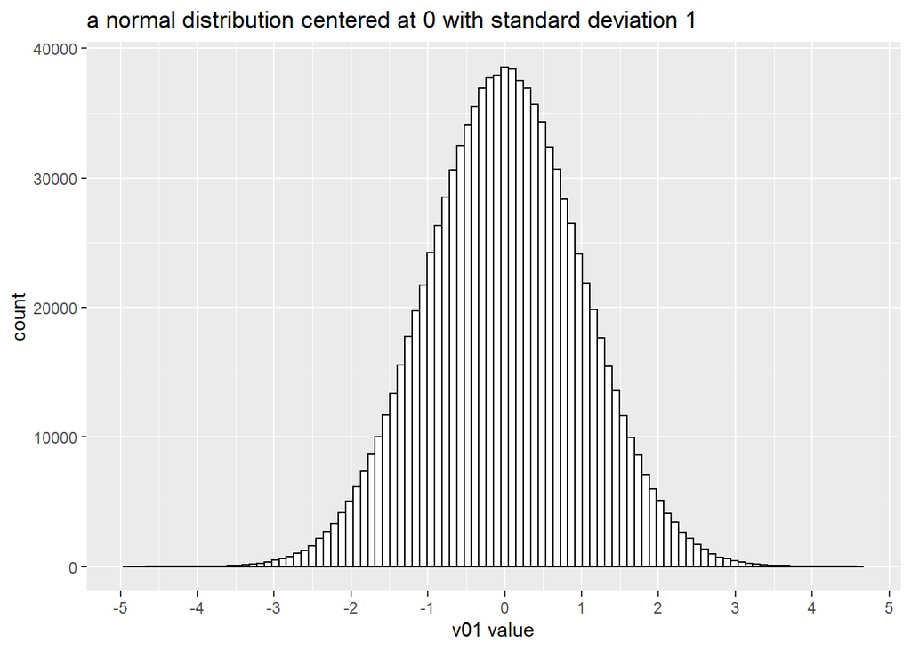

```r
ggplot(df) +
    # v01 is Normal(0, 1)
    geom_histogram(aes(x = v01),
                   colour = "black",
                   bins = 100,
                   fill = "white") +
  labs(title="a normal distribution centered at 0 with standard deviation 1") +
  scale_x_continuous(name = "v01 value", breaks = -5:5)
```

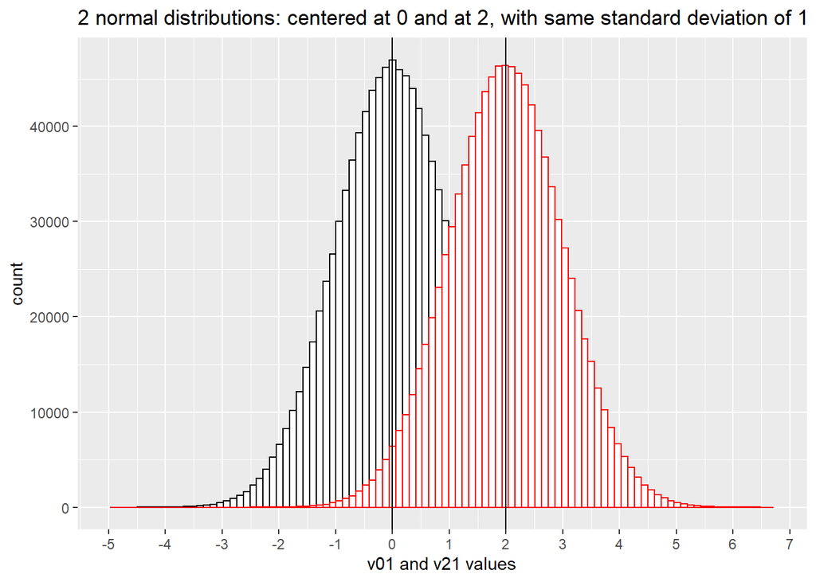

```r
ggplot(df) +
    # v1 is Normal(0, 1)
    geom_histogram(aes(x = v01),
                   colour = "black",
                   bins = 100,
                   fill = "white") +
    # v21 is Normal(2, 1)
    geom_histogram(aes(x = v21),
                   color="red",
                   bins = 100,
                   fill = "white",
                   ) +
    geom_vline(xintercept = 0) +
    geom_vline(xintercept = 2) +
  labs(title = "2 normal distributions: centered at 0 and at 2, with same standard deviation of 1") +
  scale_x_continuous(name = "v01 and v21 values", breaks = -5:7)
```

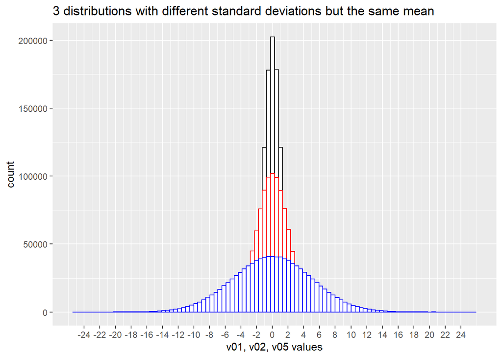

```r
ggplot(df) +
    # v01 is Normal(0, 1)
    geom_histogram(aes(x = v01),
                   colour = "black",
                   bins = 100,
                   fill = "white") +
    # v02 is Normal(0, 2)
    geom_histogram(aes(x = v02),
                   color="red",
                   bins = 100,
                   fill = "white",
                   )+
    # v05 is Normal(0, 5)
    geom_histogram(aes(x = v05),
                   color="blue",
                   bins = 100,
                   fill = "white",
                   )+
  labs(title = "3 distributions with different standard deviations but the same mean") +
scale_x_continuous(name="v01, v02, v05 values", breaks = -12:12 *2 )
```

## Density of Normal distribution

Mathematically, we have an exact representation of the Normal distribution. In R, function `dnorm` represents such “bell-shaped curve”.

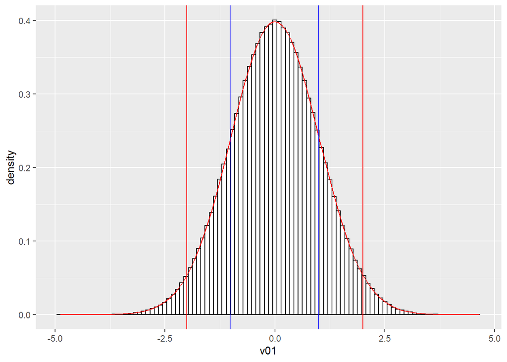

```r
ggplot(df, aes(x = v01)) +
geom_histogram(aes(y =..density..),
               colour = "black",
               bins = 100,
               fill = "white") +
    stat_function(fun = dnorm, args = list(mean = mean(df$v01), sd = sd(df$v01)), color="red") +
    geom_vline(xintercept = sd(df$v01), color='blue') +
    geom_vline(xintercept = - sd(df$v01), color='blue') +
    geom_vline(xintercept = sd(df$v01) * 2, color='red') +
    geom_vline(xintercept = - sd(df$v01) * 2, color='red')
```

# Part 3: more data manipulation exercises

## Load state level data by Sunday, 2020-09-20

```r
#install the package COVID19 and dplyr in your console [if you do not already have it in your environment]
#load it
library("COVID19")
library("dplyr")
```

```r
library("ggplot2")

#get state level data for US
US_statelevel_cases = covid19(country = "US", level = 2)
```

[output not shown]

```r
#filter state level data for US to include data only up to Sunday, Sep 20, 2020
US_statelevel_bySunday = US_statelevel_cases %>%
  filter(date<="2020-09-20")
```

## Total number of confirmed cases for each state

For this part, we will get the total number of confirmed cases for each state.

```r
#get the total number of confirmed cases for each state
State_wise_cases_1 = US_statelevel_cases %>%
  group_by(administrative_area_level_2) %>% #group by states
  summarize(total_confirmed = max(confirmed, na.rm = TRUE)) #each day's confirmed cases represent the cumulative count, get the max confirmed count for each state
State_wise_cases_1
```

```
## # A tibble: 56 x 2
##    administrative_area_level_2 total_confirmed
##    <chr>                                 <int>
##  1 Alabama                              147153
##  2 Alaska                                 7941
##  3 American Samoa                            0
##  4 Arizona                              215284
##  5 Arkansas                              77963
##  6 California                           787470
##  7 Colorado                              66053
##  8 Connecticut                           56315
##  9 Delaware                              19830
## 10 District of Columbia                  15050
## # ... with 46 more rows
```

### Exercise 1: filter by latest date (max date) and generate the total number of confirmed cases for each state

```r
the_latest_date = max(US_statelevel_cases$date)
```

```r
#you can also get the same data by filtering the data for the latest date. Try to write the code for it.
US_statelevel_cases %>%
  filter(date == max(date)) %>%
  group_by(administrative_area_level_2) %>%
  summarise(total_confirmed = confirmed)
```

```
## # A tibble: 56 x 2
##    administrative_area_level_2 total_confirmed
##    <chr>                                 <int>
##  1 Alabama                              147153
##  2 Alaska                                 7941
##  3 American Samoa                            0
##  4 Arizona                              215284
##  5 Arkansas                              77963
##  6 California                           787470
##  7 Colorado                              66053
##  8 Connecticut                           56315
##  9 Delaware                              19830
## 10 District of Columbia                  15050
## # ... with 46 more rows
```

## Calculate the Median of total confirmed cases

Notes on using `summarise()` function: 1. Don’t worry about the following warning message:

```
`summarise()` ungrouping output (override with `.groups` argument)
```

2. That `summarize()` function generates a new dataframe, and
3. That when using `summarize()`, always give names to the new columns in the new dataframe

```r
#get the median number of confirmed cases
State_median = US_statelevel_bySunday %>%
  group_by(administrative_area_level_2) %>%
  summarize(total_confirmed = max(confirmed, na.rm = TRUE)) %>% #get total confirmed like above
  summarize(median(total_confirmed, na.rm = TRUE)) #on the new column (total_confirmed), calculate the median
State_median
```

```
## # A tibble: 1 x 1
##   `median(total_confirmed, na.rm = TRUE)`
##                                     <dbl>
## 1                                  75764.
```

```r
#the result has a column with a weird name, why?
```

```r
# Create a new column with proper variable name:
State_median$median = State_median$`median(total_confirmed, na.rm = TRUE)`
```

### Collecting what we needed

```r
succinct_df = State_median[c('median')]
succinct_df
```

```
## # A tibble: 1 x 1
##   median
##    <dbl>
## 1 75764.
```

### Exercise: 2: reproduce the succinct_df

```r
# Try to reuse most of the code above and reproduce the succinct_df
State_median = US_statelevel_bySunday %>%
  group_by(administrative_area_level_2) %>%
  summarize(total_confirmed = max(confirmed, na.rm = TRUE)) %>% #get total confirmed like above
  summarize(median = median(total_confirmed, na.rm = TRUE)) #on the new column (total_confirmed), calculate the median
State_median
```

```
## # A tibble: 1 x 1
##   median
##    <dbl>
## 1 75764.
```

### How about this quick answer?

```r
# Median of the confirmed cases among the states?
median(US_statelevel_bySunday$confirmed, na.rm=TRUE)
```

```
## [1] 12059
```

```r
# What went wrong? Take a quick look at the dataframe:
# View(US_statelevel_bySunday)
```

## Ordered barplot? Can we organize the x-axis by column height?

Plot the bar chart of confirmed cases for each state arranged in ascending/increasing order

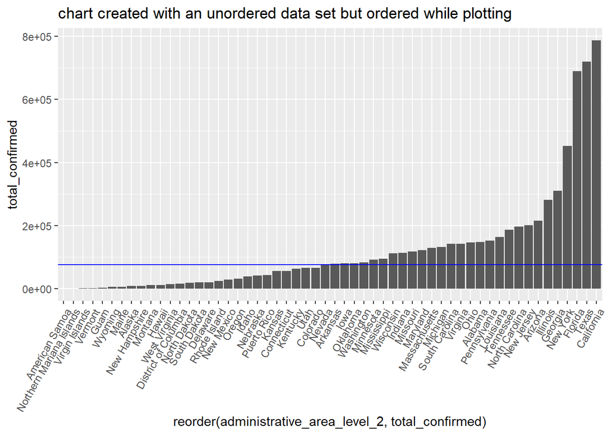

```r
#below, we are ordering the cases in the plot using the data set "State_wise_cases_1" that we created above
ggplot(State_wise_cases_1, aes(x=reorder(administrative_area_level_2,total_confirmed), y=total_confirmed))+
  geom_col()+
  theme(axis.text.x = element_text(angle=60, hjust=1))+
  geom_hline(yintercept = State_median$median, color="blue")+
  labs(title = "chart created with an unordered data set but ordered while plotting")
```

### Exercise 3: reproduce the ordered barplot

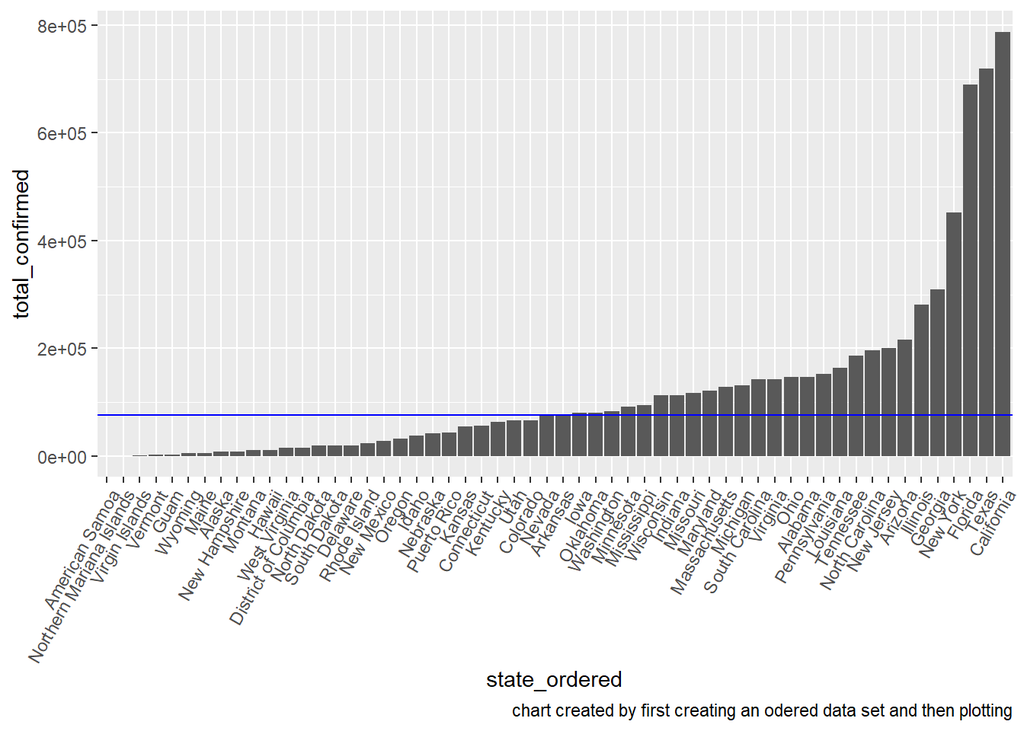

```r
# Alternative way
# Need to reconstruct the state-column as a "factor" variable, with `factor` function along with its `levels` argument
# Ref: https://rstudio-pubs-static.s3.amazonaws.com/7433_4537ea5073dc4162950abb715f513469.html
# Type your code here
State_wise_cases_1 %>%
  mutate(state_ordered =
           factor(administrative_area_level_2,
                  levels = administrative_area_level_2[order(total_confirmed)])
         )  %>%
  ggplot() +
  geom_col(mapping = aes(x = state_ordered, y = total_confirmed))+
  theme(axis.text.x = element_text(angle=60, hjust=1))+
  geom_hline(yintercept = State_median$median, color="blue")+
  labs(caption = "chart created by first creating an odered data set and then plotting")
```